# Find your prime and double prime birthday

Prime Birthday definition, we define a prime birthday as:

- when your reach an age which is a prime number (2 year old,3 year old,5th birthday,7th,11th...)
- when the year of your birthday is a prime. Double Prime Birthday:
- when both your age and the year are a prime

How frequent are prime birthday, in your lifetime and double prime ?

```python
#Check if a number is prime
# Using Sieve of Eratosthenes ( https://en.wikipedia.org/wiki/Sieve_of_Eratosthenes )
def ListPrimes(n):
    #init
    primes = [True for i in range(0,n+1)]
    for index,value in enumerate(primes):
        if index == 1 or index == 0:
            primes[index] = False
        if primes[index] == True:
            next_index = index*2
            while next_index <= n:
                primes[next_index] = False
                next_index += index
    return primes

def isPrime(n):
    primes = ListPrimes(n)
    return primes[n]
```

```python
#Basic test
isPrime(3)
```

```
True
```

```python
isPrime(458)
```

```
False
```

```python
#Based on year you are born, calculte all prime birthdays.
def prime_birthday(year_born,age_limit=125):
    primes = ListPrimes(year_born+age_limit)
    bday  = []
    count = 0
    for age in range(age_limit+1):
        if primes[age] or primes[year_born+age]:
            count += 1
            bday.append({'age':age,'year':year_born+age,'Prime age':primes[age],'Prime Year':primes[year_born+age]})
    return bday
```

```python
# example for someboday born in 1910
prime_birthday(1910)
```

```
[{'age': 2, 'year': 1912, 'Prime age': True, 'Prime Year': False},
 {'age': 3, 'year': 1913, 'Prime age': True, 'Prime Year': True},
 {'age': 5, 'year': 1915, 'Prime age': True, 'Prime Year': False},
 {'age': 7, 'year': 1917, 'Prime age': True, 'Prime Year': False},
 {'age': 11, 'year': 1921, 'Prime age': True, 'Prime Year': False},
 {'age': 13, 'year': 1923, 'Prime age': True, 'Prime Year': False},
 {'age': 17, 'year': 1927, 'Prime age': True, 'Prime Year': False},
 {'age': 19, 'year': 1929, 'Prime age': True, 'Prime Year': False},
 {'age': 21, 'year': 1931, 'Prime age': False, 'Prime Year': True},
 {'age': 23, 'year': 1933, 'Prime age': True, 'Prime Year': True},
 {'age': 29, 'year': 1939, 'Prime age': True, 'Prime Year': False},
 {'age': 31, 'year': 1941, 'Prime age': True, 'Prime Year': False},
 {'age': 37, 'year': 1947, 'Prime age': True, 'Prime Year': False},
 {'age': 39, 'year': 1949, 'Prime age': False, 'Prime Year': True},
 {'age': 41, 'year': 1951, 'Prime age': True, 'Prime Year': True},
 {'age': 43, 'year': 1953, 'Prime age': True, 'Prime Year': False},
 {'age': 47, 'year': 1957, 'Prime age': True, 'Prime Year': False},
 {'age': 53, 'year': 1963, 'Prime age': True, 'Prime Year': False},
 {'age': 59, 'year': 1969, 'Prime age': True, 'Prime Year': False},
 {'age': 61, 'year': 1971, 'Prime age': True, 'Prime Year': False},
 {'age': 63, 'year': 1973, 'Prime age': False, 'Prime Year': True},
 {'age': 67, 'year': 1977, 'Prime age': True, 'Prime Year': False},
 {'age': 69, 'year': 1979, 'Prime age': False, 'Prime Year': True},
 {'age': 71, 'year': 1981, 'Prime age': True, 'Prime Year': False},
 {'age': 73, 'year': 1983, 'Prime age': True, 'Prime Year': False},
 {'age': 77, 'year': 1987, 'Prime age': False, 'Prime Year': True},
 {'age': 79, 'year': 1989, 'Prime age': True, 'Prime Year': False},
 {'age': 83, 'year': 1993, 'Prime age': True, 'Prime Year': True},
 {'age': 87, 'year': 1997, 'Prime age': False, 'Prime Year': True},
 {'age': 89, 'year': 1999, 'Prime age': True, 'Prime Year': True},
 {'age': 93, 'year': 2003, 'Prime age': False, 'Prime Year': True},
 {'age': 97, 'year': 2007, 'Prime age': True, 'Prime Year': False},
 {'age': 101, 'year': 2011, 'Prime age': True, 'Prime Year': True},
 {'age': 103, 'year': 2013, 'Prime age': True, 'Prime Year': False},
 {'age': 107, 'year': 2017, 'Prime age': True, 'Prime Year': True},
 {'age': 109, 'year': 2019, 'Prime age': True, 'Prime Year': False},
 {'age': 113, 'year': 2023, 'Prime age': True, 'Prime Year': False},
 {'age': 117, 'year': 2027, 'Prime age': False, 'Prime Year': True},
 {'age': 119, 'year': 2029, 'Prime age': False, 'Prime Year': True}]
```

```python
#Summarize
def SumPrimeBday(year_born,age_limit=125):
    bday = prime_birthday(year_born,age_limit)
    count_prime_age = 0
    count_prime_year = 0
    count_double = 0
    for b in bday:
        if b['Prime age']:
            count_prime_age += 1
        if b['Prime Year']:
            count_prime_year += 1
        if b['Prime age'] and b['Prime Year']:
            count_double += 1
    return {'Prime Ages':count_prime_age,'Prime Years':count_prime_year,'Double':count_double}
```

```python
SumPrimeBday(1976)
```

```
{'Prime Ages': 30, 'Prime Years': 19, 'Double': 8}
```

So the number of potential prime age birthdays will be the same for everybody, 30 if you live till 125.

```python
SumPrimeBday(1970,80)
```

```
{'Prime Ages': 22, 'Prime Years': 12, 'Double': 7}
```

But only 22 if you live till 80. So the difference depending on your age will be the birth year.

```python
#Using french revolution and current year as window
pbday_by_birth_year =[SumPrimeBday(year) for year in range(1789,2020)]
```

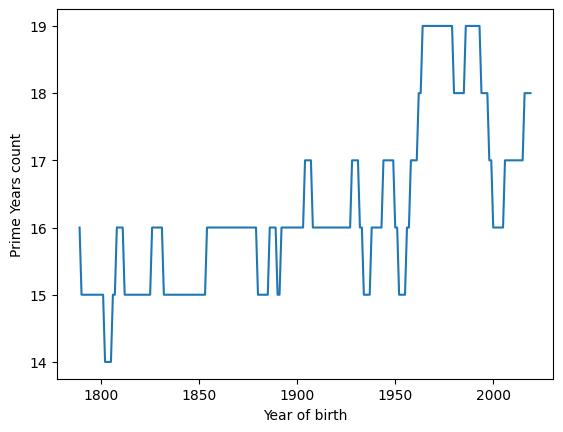

```python
#Plot
import matplotlib.pyplot as plt
%matplotlib inline

years = [year for year in range(1789,2020)]
yp = [y['Prime Years'] for y in pbday_by_birth_year]

plt.plot(years,yp)
plt.ylabel('Prime Years count')
plt.xlabel('Year of birth')
plt.show()
```

So being born in the 60/70 does provide an advantage in term of primes years you will encounter (assuming you live till 125).

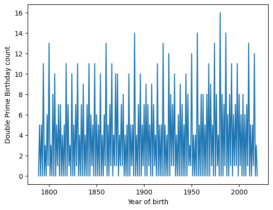

```python
yd = [y['Double'] for y in pbday_by_birth_year]

plt.plot(years,yd)
plt.ylabel('Double Prime Birthday count')
plt.xlabel('Year of birth')
plt.show()
```

```python
import math
import statistics
statistics.mean(yp)
```

```
16.25974025974026
```

```python
statistics.mean(yd)
```

```
3.8181818181818183
```

```python
print(statistics.mode(yd),statistics.mode(yp))
```

```
0 16
```

```python
print(statistics.stdev(yd),statistics.stdev(yp))
```

```
4.191276466540036 1.2792925769576962
```

```python
print(statistics.median(yd),statistics.median(yp))
```

```
1 16
```

```python
no_double = [years[index] for index,value in enumerate(yd) if value == 0]
```

```python
#People born in those years will have no double prime birthday !!
print(no_double)
```

[output not shown]

```
(0.0, 90.0)
```

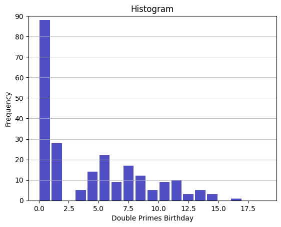

```python
import numpy as np
# An "interface" to matplotlib.axes.Axes.hist() method
n, bins, patches = plt.hist(x=yd, bins=[i for i in range(20)], color='#0504aa',
                            alpha=0.7, rwidth=0.85)
plt.grid(axis='y', alpha=0.75)
plt.xlabel('Double Primes Birthday')
plt.ylabel('Frequency')
plt.title('Histogram')
maxfreq = n.max()
# Set a clean upper y-axis limit.
plt.ylim(ymax=np.ceil(maxfreq / 10) * 10 if maxfreq % 10 else maxfreq + 10)
```

```python
len(no_double)
```

```
88
```

So between 1789 and 2020, 88 years will result in no double prime birthdays over 231 years.